# Risk Factor Analysis

## Outcome Variable

**Outcome Variable:** co_occurence

## Predictor Variables

**Intervention Variable:** ever_sunderweight06

**Adjustment Set:**

unadjusted

## Stratifying Variables

The analysis was stratified on these variable(s):

- studyid
- country

## Data Summary

| studyid | country | ever_sunderweight06 | co_occurence | n_cell | n |
| --- | --- | --- | --- | --- | --- |
| ki0047075b-MAL-ED | BANGLADESH | 0 | 0 | 199 | 221 |
| ki0047075b-MAL-ED | BANGLADESH | 0 | 1 | 11 | 221 |
| ki0047075b-MAL-ED | BANGLADESH | 1 | 0 | 8 | 221 |
| ki0047075b-MAL-ED | BANGLADESH | 1 | 1 | 3 | 221 |
| ki0047075b-MAL-ED | BRAZIL | 0 | 0 | 179 | 180 |
| ki0047075b-MAL-ED | BRAZIL | 0 | 1 | 1 | 180 |
| ki0047075b-MAL-ED | BRAZIL | 1 | 0 | 0 | 180 |
| ki0047075b-MAL-ED | BRAZIL | 1 | 1 | 0 | 180 |
| ki0047075b-MAL-ED | INDIA | 0 | 0 | 189 | 228 |
| ki0047075b-MAL-ED | INDIA | 0 | 1 | 10 | 228 |
| ki0047075b-MAL-ED | INDIA | 1 | 0 | 22 | 228 |
| ki0047075b-MAL-ED | INDIA | 1 | 1 | 7 | 228 |
| ki0047075b-MAL-ED | NEPAL | 0 | 0 | 217 | 229 |
| ki0047075b-MAL-ED | NEPAL | 0 | 1 | 2 | 229 |
| ki0047075b-MAL-ED | NEPAL | 1 | 0 | 8 | 229 |
| ki0047075b-MAL-ED | NEPAL | 1 | 1 | 2 | 229 |
| ki0047075b-MAL-ED | PERU | 0 | 0 | 211 | 222 |
| ki0047075b-MAL-ED | PERU | 0 | 1 | 4 | 222 |
| ki0047075b-MAL-ED | PERU | 1 | 0 | 5 | 222 |
| ki0047075b-MAL-ED | PERU | 1 | 1 | 2 | 222 |
| ki0047075b-MAL-ED | SOUTH AFRICA | 0 | 0 | 230 | 241 |
| ki0047075b-MAL-ED | SOUTH AFRICA | 0 | 1 | 4 | 241 |
| ki0047075b-MAL-ED | SOUTH AFRICA | 1 | 0 | 7 | 241 |
| ki0047075b-MAL-ED | SOUTH AFRICA | 1 | 1 | 0 | 241 |
| ki0047075b-MAL-ED | TANZANIA, UNITED REPUBLIC OF | 0 | 0 | 218 | 225 |
| ki0047075b-MAL-ED | TANZANIA, UNITED REPUBLIC OF | 0 | 1 | 0 | 225 |
| ki0047075b-MAL-ED | TANZANIA, UNITED REPUBLIC OF | 1 | 0 | 6 | 225 |
| ki0047075b-MAL-ED | TANZANIA, UNITED REPUBLIC OF | 1 | 1 | 1 | 225 |
| ki1000108-CMC-V-BCS-2002 | INDIA | 0 | 0 | 288 | 369 |
| ki1000108-CMC-V-BCS-2002 | INDIA | 0 | 1 | 8 | 369 |

[output cut: 102 more lines]

The following strata were considered:

- studyid: ki0047075b-MAL-ED, country: BANGLADESH
- studyid: ki0047075b-MAL-ED, country: BRAZIL
- studyid: ki0047075b-MAL-ED, country: INDIA
- studyid: ki0047075b-MAL-ED, country: NEPAL
- studyid: ki0047075b-MAL-ED, country: PERU
- studyid: ki0047075b-MAL-ED, country: SOUTH AFRICA
- studyid: ki0047075b-MAL-ED, country: TANZANIA, UNITED REPUBLIC OF
- studyid: ki1000108-CMC-V-BCS-2002, country: INDIA
- studyid: ki1000108-IRC, country: INDIA
- studyid: ki1000109-EE, country: PAKISTAN
- studyid: ki1000109-ResPak, country: PAKISTAN
- studyid: ki1000304b-SAS-CompFeed, country: INDIA
- studyid: ki1000304b-SAS-FoodSuppl, country: INDIA
- studyid: ki1017093-NIH-Birth, country: BANGLADESH
- studyid: ki1017093b-PROVIDE, country: BANGLADESH
- studyid: ki1017093c-NIH-Crypto, country: BANGLADESH
- studyid: ki1066203-TanzaniaChild2, country: TANZANIA, UNITED REPUBLIC OF
- studyid: ki1101329-Keneba, country: GAMBIA
- studyid: ki1112895-Burkina Faso Zn, country: BURKINA FASO
- studyid: ki1113344-GMS-Nepal, country: NEPAL
- studyid: ki1114097-CMIN, country: BANGLADESH
- studyid: ki1114097-CMIN, country: BRAZIL
- studyid: ki1114097-CMIN, country: GUINEA-BISSAU
- studyid: ki1114097-CMIN, country: PERU
- studyid: ki1114097-CONTENT, country: PERU
- studyid: ki1119695-PROBIT, country: BELARUS
- studyid: ki1126311-ZVITAMBO, country: ZIMBABWE
- studyid: ki1135781-COHORTS, country: GUATEMALA
- studyid: ki1135781-COHORTS, country: PHILIPPINES
- studyid: ki1148112-iLiNS-DOSE, country: MALAWI
- studyid: ki1148112-iLiNS-DYAD-M, country: MALAWI
- studyid: ki1148112-LCNI-5, country: MALAWI
- studyid: kiGH5241-JiVitA-4, country: BANGLADESH

### Dropped Strata

Some strata were dropped due to rare outcomes:

- studyid: ki0047075b-MAL-ED, country: BANGLADESH
- studyid: ki0047075b-MAL-ED, country: BRAZIL
- studyid: ki0047075b-MAL-ED, country: NEPAL
- studyid: ki0047075b-MAL-ED, country: PERU
- studyid: ki0047075b-MAL-ED, country: SOUTH AFRICA
- studyid: ki0047075b-MAL-ED, country: TANZANIA, UNITED REPUBLIC OF
- studyid: ki1000109-ResPak, country: PAKISTAN
- studyid: ki1066203-TanzaniaChild2, country: TANZANIA, UNITED REPUBLIC OF
- studyid: ki1112895-Burkina Faso Zn, country: BURKINA FASO
- studyid: ki1114097-CMIN, country: BRAZIL
- studyid: ki1114097-CMIN, country: GUINEA-BISSAU
- studyid: ki1114097-CMIN, country: PERU
- studyid: ki1114097-CONTENT, country: PERU
- studyid: ki1119695-PROBIT, country: BELARUS
- studyid: ki1148112-iLiNS-DOSE, country: MALAWI
- studyid: ki1148112-iLiNS-DYAD-M, country: MALAWI
- studyid: ki1148112-LCNI-5, country: MALAWI

## Methods Detail

We’re interested in the causal parameters $E[Y_a]$ for all values of $a \in \mathcal{A}$. These parameters represent the mean outcome if, possibly contrary to fact, we intervened to set all units to have $A=a$. Under the randomization and positivity assumptions, these are identified by the statistical parameters $\psi_a=E_W[E_{Y|A,W}(Y|A=a,W)]$. In addition, we’re interested in the mean of $Y$, $E[Y]$ under no intervention (the observed mean). We will estimate these parameters by using SuperLearner to fit the relevant likelihood factors – $E_{Y|A,W}(Y|A=a,W)$ and $p(A=a|W)$, and then updating our likelihood fit using a joint TMLE.

For unadjusted analyses ($W=\{\}$), initial likelihoods were estimated using Lrnr_glm to estimate the simple $E(Y|A)$ and Lrnr_mean to estimate $p(A)$. For adjusted analyses, a small library containing Lrnr_glmnet, Lrnr_xgboost, and Lrnr_mean was used.

Having estimated these parameters, we will then use the delta method to estimate relative risks and attributable risks relative to a prespecified baseline level of $A$.

# Results Detail

## Results Plots

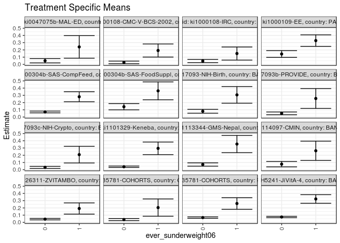

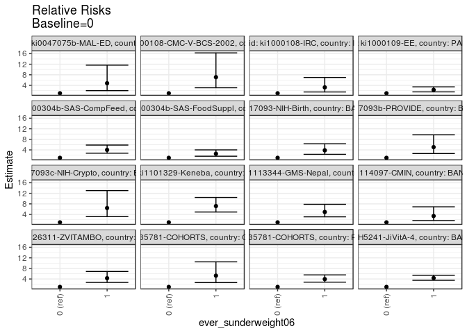

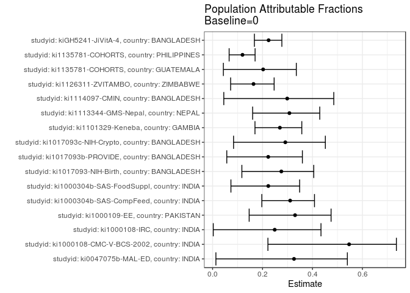

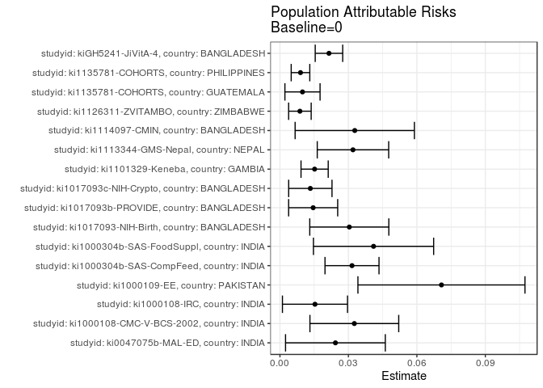

## Results Table

### Parameter: TSM

| studyid | country | intervention_level | baseline_level | estimate | ci_lower | ci_upper |
| --- | --- | --- | --- | --- | --- | --- |
| ki0047075b-MAL-ED | INDIA | 0 | NA | 0.0502513 | 0.0198316 | 0.0806709 |
| ki0047075b-MAL-ED | INDIA | 1 | NA | 0.2413793 | 0.0852926 | 0.3974660 |
| ki1000108-CMC-V-BCS-2002 | INDIA | 0 | NA | 0.0270270 | 0.0085283 | 0.0455257 |
| ki1000108-CMC-V-BCS-2002 | INDIA | 1 | NA | 0.1917808 | 0.1013445 | 0.2822172 |
| ki1000108-IRC | INDIA | 0 | NA | 0.0463768 | 0.0241583 | 0.0685953 |
| ki1000108-IRC | INDIA | 1 | NA | 0.1500000 | 0.0595384 | 0.2404616 |
| ki1000109-EE | PAKISTAN | 0 | NA | 0.1435185 | 0.0966959 | 0.1903411 |
| ki1000109-EE | PAKISTAN | 1 | NA | 0.3283582 | 0.2487313 | 0.4079851 |
| ki1000304b-SAS-CompFeed | INDIA | 0 | NA | 0.0700935 | 0.0579658 | 0.0822211 |
| ki1000304b-SAS-CompFeed | INDIA | 1 | NA | 0.2804233 | 0.2114211 | 0.3494255 |
| ki1000304b-SAS-FoodSuppl | INDIA | 0 | NA | 0.1428571 | 0.0995831 | 0.1861311 |
| ki1000304b-SAS-FoodSuppl | INDIA | 1 | NA | 0.3620690 | 0.2381841 | 0.4859538 |
| ki1017093-NIH-Birth | BANGLADESH | 0 | NA | 0.0800000 | 0.0533849 | 0.1066151 |
| ki1017093-NIH-Birth | BANGLADESH | 1 | NA | 0.3064516 | 0.1915722 | 0.4213310 |
| ki1017093b-PROVIDE | BANGLADESH | 0 | NA | 0.0507813 | 0.0317467 | 0.0698158 |
| ki1017093b-PROVIDE | BANGLADESH | 1 | NA | 0.2564103 | 0.1192448 | 0.3935757 |
| ki1017093c-NIH-Crypto | BANGLADESH | 0 | NA | 0.0324232 | 0.0180712 | 0.0467752 |
| ki1017093c-NIH-Crypto | BANGLADESH | 1 | NA | 0.2083333 | 0.0933537 | 0.3233129 |
| ki1101329-Keneba | GAMBIA | 0 | NA | 0.0411872 | 0.0315988 | 0.0507756 |
| ki1101329-Keneba | GAMBIA | 1 | NA | 0.2952381 | 0.2079642 | 0.3825120 |
| ki1113344-GMS-Nepal | NEPAL | 0 | NA | 0.0720165 | 0.0490120 | 0.0950210 |
| ki1113344-GMS-Nepal | NEPAL | 1 | NA | 0.3548387 | 0.2356326 | 0.4740448 |
| ki1114097-CMIN | BANGLADESH | 0 | NA | 0.0769231 | 0.0394434 | 0.1144028 |
| ki1114097-CMIN | BANGLADESH | 1 | NA | 0.2619048 | 0.1286541 | 0.3951555 |
| ki1126311-ZVITAMBO | ZIMBABWE | 0 | NA | 0.0446429 | 0.0344178 | 0.0548679 |
| ki1126311-ZVITAMBO | ZIMBABWE | 1 | NA | 0.1919192 | 0.1143218 | 0.2695166 |
| ki1135781-COHORTS | GUATEMALA | 0 | NA | 0.0389049 | 0.0245087 | 0.0533011 |
| ki1135781-COHORTS | GUATEMALA | 1 | NA | 0.2045455 | 0.0852789 | 0.3238120 |
| ki1135781-COHORTS | PHILIPPINES | 0 | NA | 0.0661889 | 0.0561820 | 0.0761958 |
| ki1135781-COHORTS | PHILIPPINES | 1 | NA | 0.2608696 | 0.1805986 | 0.3411406 |
| kiGH5241-JiVitA-4 | BANGLADESH | 0 | NA | 0.0742927 | 0.0651211 | 0.0834644 |
| kiGH5241-JiVitA-4 | BANGLADESH | 1 | NA | 0.3237598 | 0.2641086 | 0.3834110 |

### Parameter: E(Y)

| studyid | country | intervention_level | baseline_level | estimate | ci_lower | ci_upper |
| --- | --- | --- | --- | --- | --- | --- |
| ki0047075b-MAL-ED | INDIA | NA | NA | 0.0745614 | 0.0403897 | 0.1087331 |
| ki1000108-CMC-V-BCS-2002 | INDIA | NA | NA | 0.0596206 | 0.0354285 | 0.0838127 |
| ki1000108-IRC | INDIA | NA | NA | 0.0617284 | 0.0382610 | 0.0851958 |
| ki1000109-EE | PAKISTAN | NA | NA | 0.2142857 | 0.1712366 | 0.2573348 |
| ki1000304b-SAS-CompFeed | INDIA | NA | NA | 0.1016680 | 0.0902317 | 0.1131043 |
| ki1000304b-SAS-FoodSuppl | INDIA | NA | NA | 0.1838710 | 0.1406788 | 0.2270631 |
| ki1017093-NIH-Birth | BANGLADESH | NA | NA | 0.1103896 | 0.0817833 | 0.1389959 |
| ki1017093b-PROVIDE | BANGLADESH | NA | NA | 0.0653358 | 0.0446834 | 0.0859881 |
| ki1017093c-NIH-Crypto | BANGLADESH | NA | NA | 0.0457413 | 0.0294659 | 0.0620168 |
| ki1101329-Keneba | GAMBIA | NA | NA | 0.0563781 | 0.0455871 | 0.0671692 |
| ki1113344-GMS-Nepal | NEPAL | NA | NA | 0.1040146 | 0.0784316 | 0.1295976 |
| ki1114097-CMIN | BANGLADESH | NA | NA | 0.1097046 | 0.0698323 | 0.1495770 |
| ki1126311-ZVITAMBO | ZIMBABWE | NA | NA | 0.0533893 | 0.0425943 | 0.0641843 |
| ki1135781-COHORTS | GUATEMALA | NA | NA | 0.0487805 | 0.0332288 | 0.0643322 |
| ki1135781-COHORTS | PHILIPPINES | NA | NA | 0.0751910 | 0.0648251 | 0.0855569 |
| kiGH5241-JiVitA-4 | BANGLADESH | NA | NA | 0.0957734 | 0.0852493 | 0.1062974 |

### Parameter: RR

| studyid | country | intervention_level | baseline_level | estimate | ci_lower | ci_upper |
| --- | --- | --- | --- | --- | --- | --- |
| ki0047075b-MAL-ED | INDIA | 0 | 0 | 1.000000 | 1.000000 | 1.000000 |
| ki0047075b-MAL-ED | INDIA | 1 | 0 | 4.803448 | 1.980913 | 11.647715 |
| ki1000108-CMC-V-BCS-2002 | INDIA | 0 | 0 | 1.000000 | 1.000000 | 1.000000 |
| ki1000108-CMC-V-BCS-2002 | INDIA | 1 | 0 | 7.095890 | 3.090539 | 16.292192 |
| ki1000108-IRC | INDIA | 0 | 0 | 1.000000 | 1.000000 | 1.000000 |
| ki1000108-IRC | INDIA | 1 | 0 | 3.234375 | 1.497241 | 6.986971 |
| ki1000109-EE | PAKISTAN | 0 | 0 | 1.000000 | 1.000000 | 1.000000 |
| ki1000109-EE | PAKISTAN | 1 | 0 | 2.287915 | 1.523696 | 3.435433 |
| ki1000304b-SAS-CompFeed | INDIA | 0 | 0 | 1.000000 | 1.000000 | 1.000000 |
| ki1000304b-SAS-CompFeed | INDIA | 1 | 0 | 4.000705 | 2.741980 | 5.837258 |
| ki1000304b-SAS-FoodSuppl | INDIA | 0 | 0 | 1.000000 | 1.000000 | 1.000000 |
| ki1000304b-SAS-FoodSuppl | INDIA | 1 | 0 | 2.534483 | 1.604815 | 4.002705 |
| ki1017093-NIH-Birth | BANGLADESH | 0 | 0 | 1.000000 | 1.000000 | 1.000000 |
| ki1017093-NIH-Birth | BANGLADESH | 1 | 0 | 3.830645 | 2.320600 | 6.323295 |
| ki1017093b-PROVIDE | BANGLADESH | 0 | 0 | 1.000000 | 1.000000 | 1.000000 |
| ki1017093b-PROVIDE | BANGLADESH | 1 | 0 | 5.049310 | 2.627556 | 9.703134 |
| ki1017093c-NIH-Crypto | BANGLADESH | 0 | 0 | 1.000000 | 1.000000 | 1.000000 |
| ki1017093c-NIH-Crypto | BANGLADESH | 1 | 0 | 6.425439 | 3.166992 | 13.036427 |
| ki1101329-Keneba | GAMBIA | 0 | 0 | 1.000000 | 1.000000 | 1.000000 |
| ki1101329-Keneba | GAMBIA | 1 | 0 | 7.168207 | 4.920382 | 10.442927 |
| ki1113344-GMS-Nepal | NEPAL | 0 | 0 | 1.000000 | 1.000000 | 1.000000 |
| ki1113344-GMS-Nepal | NEPAL | 1 | 0 | 4.927189 | 3.099371 | 7.832941 |
| ki1114097-CMIN | BANGLADESH | 0 | 0 | 1.000000 | 1.000000 | 1.000000 |
| ki1114097-CMIN | BANGLADESH | 1 | 0 | 3.404762 | 1.683245 | 6.886936 |
| ki1126311-ZVITAMBO | ZIMBABWE | 0 | 0 | 1.000000 | 1.000000 | 1.000000 |
| ki1126311-ZVITAMBO | ZIMBABWE | 1 | 0 | 4.298990 | 2.701183 | 6.841933 |
| ki1135781-COHORTS | GUATEMALA | 0 | 0 | 1.000000 | 1.000000 | 1.000000 |
| ki1135781-COHORTS | GUATEMALA | 1 | 0 | 5.257576 | 2.635527 | 10.488263 |
| ki1135781-COHORTS | PHILIPPINES | 0 | 0 | 1.000000 | 1.000000 | 1.000000 |
| ki1135781-COHORTS | PHILIPPINES | 1 | 0 | 3.941291 | 2.797334 | 5.553063 |
| kiGH5241-JiVitA-4 | BANGLADESH | 0 | 0 | 1.000000 | 1.000000 | 1.000000 |
| kiGH5241-JiVitA-4 | BANGLADESH | 1 | 0 | 4.357893 | 3.504082 | 5.419744 |

### Parameter: PAR

| studyid | country | intervention_level | baseline_level | estimate | ci_lower | ci_upper |
| --- | --- | --- | --- | --- | --- | --- |
| ki0047075b-MAL-ED | INDIA | 0 | NA | 0.0243101 | 0.0024528 | 0.0461675 |
| ki1000108-CMC-V-BCS-2002 | INDIA | 0 | NA | 0.0325936 | 0.0131397 | 0.0520475 |
| ki1000108-IRC | INDIA | 0 | NA | 0.0153516 | 0.0010923 | 0.0296108 |
| ki1000109-EE | PAKISTAN | 0 | NA | 0.0707672 | 0.0341668 | 0.1073676 |
| ki1000304b-SAS-CompFeed | INDIA | 0 | NA | 0.0315745 | 0.0197432 | 0.0434058 |
| ki1000304b-SAS-FoodSuppl | INDIA | 0 | NA | 0.0410138 | 0.0146765 | 0.0673511 |
| ki1017093-NIH-Birth | BANGLADESH | 0 | NA | 0.0303896 | 0.0130667 | 0.0477125 |
| ki1017093b-PROVIDE | BANGLADESH | 0 | NA | 0.0145545 | 0.0038076 | 0.0253014 |
| ki1017093c-NIH-Crypto | BANGLADESH | 0 | NA | 0.0133181 | 0.0038260 | 0.0228102 |
| ki1101329-Keneba | GAMBIA | 0 | NA | 0.0151910 | 0.0092324 | 0.0211495 |
| ki1113344-GMS-Nepal | NEPAL | 0 | NA | 0.0319981 | 0.0163446 | 0.0476517 |
| ki1114097-CMIN | BANGLADESH | 0 | NA | 0.0327816 | 0.0066482 | 0.0589149 |
| ki1126311-ZVITAMBO | ZIMBABWE | 0 | NA | 0.0087465 | 0.0038069 | 0.0136861 |
| ki1135781-COHORTS | GUATEMALA | 0 | NA | 0.0098756 | 0.0021738 | 0.0175774 |
| ki1135781-COHORTS | PHILIPPINES | 0 | NA | 0.0090021 | 0.0049310 | 0.0130733 |
| kiGH5241-JiVitA-4 | BANGLADESH | 0 | NA | 0.0214806 | 0.0154627 | 0.0274986 |

### Parameter: PAF

| studyid | country | intervention_level | baseline_level | estimate | ci_lower | ci_upper |
| --- | --- | --- | --- | --- | --- | --- |
| ki0047075b-MAL-ED | INDIA | 0 | NA | 0.3260420 | 0.0132207 | 0.5396950 |
| ki1000108-CMC-V-BCS-2002 | INDIA | 0 | NA | 0.5466830 | 0.2215195 | 0.7360290 |
| ki1000108-IRC | INDIA | 0 | NA | 0.2486956 | 0.0026326 | 0.4340518 |
| ki1000109-EE | PAKISTAN | 0 | NA | 0.3302469 | 0.1464420 | 0.4744713 |
| ki1000304b-SAS-CompFeed | INDIA | 0 | NA | 0.3105651 | 0.1970285 | 0.4080482 |
| ki1000304b-SAS-FoodSuppl | INDIA | 0 | NA | 0.2230576 | 0.0733943 | 0.3485477 |
| ki1017093-NIH-Birth | BANGLADESH | 0 | NA | 0.2752941 | 0.1171998 | 0.4050764 |
| ki1017093b-PROVIDE | BANGLADESH | 0 | NA | 0.2227648 | 0.0567607 | 0.3595532 |
| ki1017093c-NIH-Crypto | BANGLADESH | 0 | NA | 0.2911616 | 0.0838895 | 0.4515379 |
| ki1101329-Keneba | GAMBIA | 0 | NA | 0.2694480 | 0.1696995 | 0.3572131 |
| ki1113344-GMS-Nepal | NEPAL | 0 | NA | 0.3076312 | 0.1602952 | 0.4291154 |
| ki1114097-CMIN | BANGLADESH | 0 | NA | 0.2988166 | 0.0448005 | 0.4852822 |
| ki1126311-ZVITAMBO | ZIMBABWE | 0 | NA | 0.1638242 | 0.0721545 | 0.2464371 |
| ki1135781-COHORTS | GUATEMALA | 0 | NA | 0.2024496 | 0.0431095 | 0.3352566 |
| ki1135781-COHORTS | PHILIPPINES | 0 | NA | 0.1197234 | 0.0662166 | 0.1701643 |
| kiGH5241-JiVitA-4 | BANGLADESH | 0 | NA | 0.2242861 | 0.1673494 | 0.2773295 |